# Class 8: Unsupervised Learning Analysis of Human Breast Cancer Cells

Author

Sophia Choi

Published

April 26, 2026

# 1 Overview

This mini-project uses unsupervised learning (PCA + hierarchical clustering) on the Wisconsin Breast Cancer Diagnostic Data Set. Features describe cell nuclei from fine needle aspiration (FNA) biopsies of breast masses, with each sample labeled by a pathologist as **M** (malignant) or **B** (benign). We will *not* use that label for clustering, only to evaluate our unsupervised results at the end.

# 2 Exploratory data analysis

## 2.1 Preparing the data

```r
fna.data <- "WisconsinCancer.csv"
wisc.df <- read.csv(fna.data, row.names=1)
head(wisc.df, 4)
```

```
         diagnosis radius_mean texture_mean perimeter_mean area_mean
842302           M       17.99        10.38         122.80    1001.0
842517           M       20.57        17.77         132.90    1326.0
84300903         M       19.69        21.25         130.00    1203.0
84348301         M       11.42        20.38          77.58     386.1
         smoothness_mean compactness_mean concavity_mean concave.points_mean
842302           0.11840          0.27760         0.3001             0.14710
842517           0.08474          0.07864         0.0869             0.07017
84300903         0.10960          0.15990         0.1974             0.12790
84348301         0.14250          0.28390         0.2414             0.10520
         symmetry_mean fractal_dimension_mean radius_se texture_se perimeter_se
842302          0.2419                0.07871    1.0950     0.9053        8.589
842517          0.1812                0.05667    0.5435     0.7339        3.398
84300903        0.2069                0.05999    0.7456     0.7869        4.585
84348301        0.2597                0.09744    0.4956     1.1560        3.445
```

[output cut: 25 more lines]

Drop the expert `diagnosis` column so we don’t accidentally use it during the unsupervised analysis, and save it separately as a factor for later checks.

```r
wisc.data <- wisc.df[, -1]
diagnosis <- as.factor(wisc.df$diagnosis)
```

## 2.2 Q1. How many observations are in this dataset?

```r
nrow(wisc.data)
```

```
[1] 569
```

> **Answer:** There are **569 observations** in the dataset.

## 2.3 Q2. How many of the observations have a malignant diagnosis?

```r
table(diagnosis)
```

```
diagnosis
  B   M
357 212
```

```r
sum(diagnosis == "M")
```

```
[1] 212
```

> **Answer:** **212 of the 569 observations** have a malignant (`M`) diagnosis (the remaining 357 are benign).

## 2.4 Q3. How many variables/features in the data are suffixed with `_mean`?

```r
length(grep("_mean$", colnames(wisc.data)))
```

```
[1] 10
```

> **Answer:** **10 features** are suffixed with `_mean` (one per measurement type: `radius_mean`, `texture_mean`, `perimeter_mean`, `area_mean`, `smoothness_mean`, `compactness_mean`, `concavity_mean`, `concave.points_mean`, `symmetry_mean`, `fractal_dimension_mean`).

# 3 Principal Component Analysis

## 3.1 Performing PCA

Check whether we need to scale, features have very different means/variances, so yes.

```r
round(colMeans(wisc.data), 3)
```

```
            radius_mean            texture_mean          perimeter_mean
                 14.127                  19.290                  91.969
              area_mean         smoothness_mean        compactness_mean
                654.889                   0.096                   0.104
         concavity_mean     concave.points_mean           symmetry_mean
                  0.089                   0.049                   0.181
 fractal_dimension_mean               radius_se              texture_se
                  0.063                   0.405                   1.217
           perimeter_se                 area_se           smoothness_se
                  2.866                  40.337                   0.007
         compactness_se            concavity_se       concave.points_se
                  0.025                   0.032                   0.012
            symmetry_se    fractal_dimension_se            radius_worst
                  0.021                   0.004                  16.269
          texture_worst         perimeter_worst              area_worst
                 25.677                 107.261                 880.583
       smoothness_worst       compactness_worst         concavity_worst
                  0.132                   0.254                   0.272
   concave.points_worst          symmetry_worst fractal_dimension_worst
                  0.115                   0.290                   0.084
```

```r
round(apply(wisc.data, 2, sd), 3)
```

```
            radius_mean            texture_mean          perimeter_mean
                  3.524                   4.301                  24.299
              area_mean         smoothness_mean        compactness_mean
                351.914                   0.014                   0.053
         concavity_mean     concave.points_mean           symmetry_mean
                  0.080                   0.039                   0.027
 fractal_dimension_mean               radius_se              texture_se
                  0.007                   0.277                   0.552
           perimeter_se                 area_se           smoothness_se
                  2.022                  45.491                   0.003
         compactness_se            concavity_se       concave.points_se
                  0.018                   0.030                   0.006
            symmetry_se    fractal_dimension_se            radius_worst
                  0.008                   0.003                   4.833
          texture_worst         perimeter_worst              area_worst
                  6.146                  33.603                 569.357
       smoothness_worst       compactness_worst         concavity_worst
                  0.023                   0.157                   0.209
   concave.points_worst          symmetry_worst fractal_dimension_worst
                  0.066                   0.062                   0.018
```

```r
wisc.pr <- prcomp(wisc.data, scale = TRUE)
summary(wisc.pr)
```

```
Importance of components:
                          PC1    PC2     PC3     PC4     PC5     PC6     PC7
Standard deviation     3.6444 2.3857 1.67867 1.40735 1.28403 1.09880 0.82172
Proportion of Variance 0.4427 0.1897 0.09393 0.06602 0.05496 0.04025 0.02251
Cumulative Proportion  0.4427 0.6324 0.72636 0.79239 0.84734 0.88759 0.91010
                           PC8    PC9    PC10   PC11    PC12    PC13    PC14
Standard deviation     0.69037 0.6457 0.59219 0.5421 0.51104 0.49128 0.39624
Proportion of Variance 0.01589 0.0139 0.01169 0.0098 0.00871 0.00805 0.00523
Cumulative Proportion  0.92598 0.9399 0.95157 0.9614 0.97007 0.97812 0.98335
                          PC15    PC16    PC17    PC18    PC19    PC20   PC21
Standard deviation     0.30681 0.28260 0.24372 0.22939 0.22244 0.17652 0.1731
Proportion of Variance 0.00314 0.00266 0.00198 0.00175 0.00165 0.00104 0.0010
Cumulative Proportion  0.98649 0.98915 0.99113 0.99288 0.99453 0.99557 0.9966
                          PC22    PC23   PC24    PC25    PC26    PC27    PC28
Standard deviation     0.16565 0.15602 0.1344 0.12442 0.09043 0.08307 0.03987
Proportion of Variance 0.00091 0.00081 0.0006 0.00052 0.00027 0.00023 0.00005
Cumulative Proportion  0.99749 0.99830 0.9989 0.99942 0.99969 0.99992 0.99997
                          PC29    PC30
Standard deviation     0.02736 0.01153
Proportion of Variance 0.00002 0.00000
Cumulative Proportion  1.00000 1.00000
```

## 3.2 Q4. Proportion of variance captured by PC1?

> **Answer:** PC1 captures **44.27%** of the total variance (0.4427).

## 3.3 Q5. How many PCs are required to describe at least 70% of the variance?

> **Answer:** **3 PCs**, the cumulative proportion reaches 72.64% at PC3 (PC1 + PC2 + PC3 = 44.27% + 18.97% + 9.39%).

## 3.4 Q6. How many PCs are required to describe at least 90% of the variance?

> **Answer:** **7 PCs**, the cumulative proportion reaches 91.01% at PC7.

## 3.5 Interpreting PCA results

A biplot is typically hard to read for data of this size:

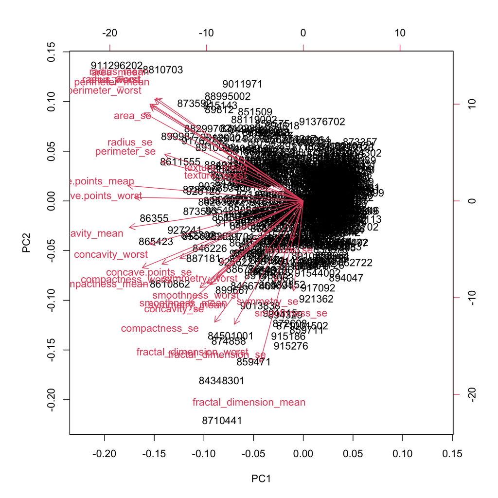

```r
biplot(wisc.pr)
```

## 3.6 Q7. What stands out in the biplot? Is it easy or difficult to understand?

> **Answer:** It is **very difficult to understand**. With 569 observations `biplot()` uses the row names (patient IDs) as the plotting symbol, so the samples overlap into a dense blob, and all 30 feature-loading arrows fan out on top of them. There is no obvious grouping visible, and the patient IDs carry no biological meaning. A clean PC1-vs-PC2 scatter plot colored by diagnosis (below) is far more informative.

A much cleaner PC1 vs PC2 scatter plot, colored by diagnosis:

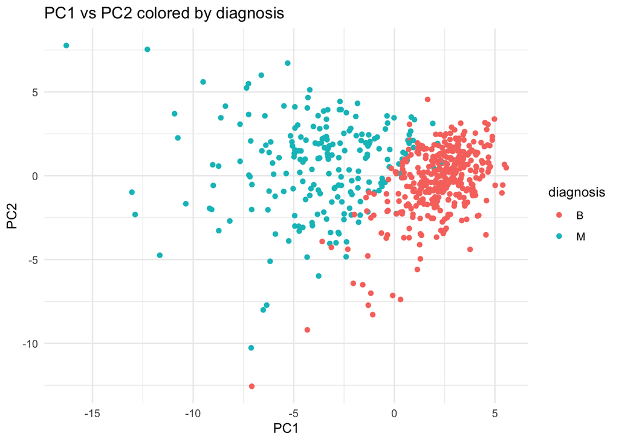

```r
library(ggplot2)
ggplot(as.data.frame(wisc.pr$x)) +
  aes(PC1, PC2, col = diagnosis) +
  geom_point() +
  theme_minimal() +
  labs(title = "PC1 vs PC2 colored by diagnosis")
```

## 3.7 Q8. Generate a similar plot for PC1 vs PC3. What do you notice?

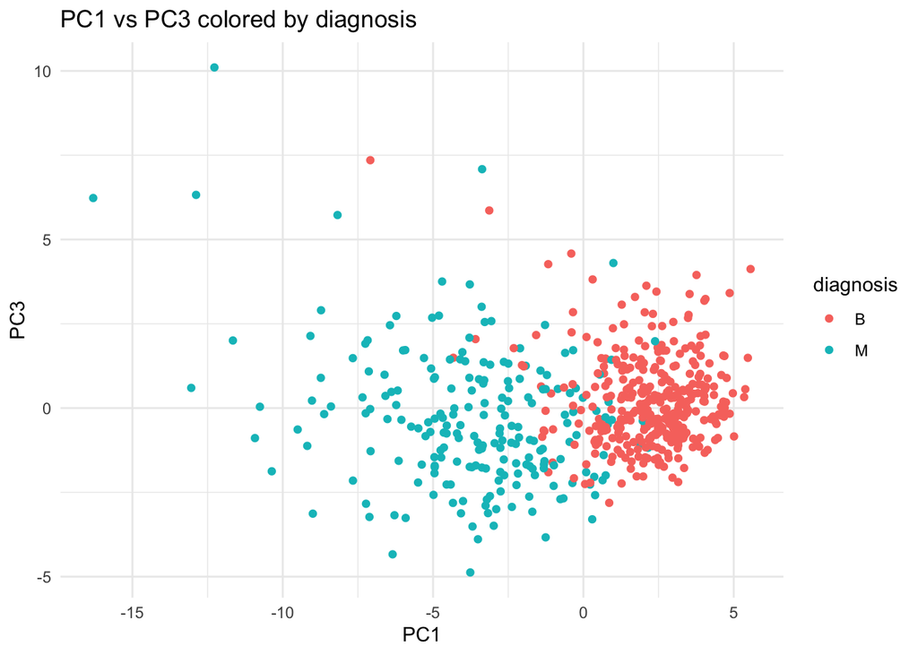

```r
ggplot(as.data.frame(wisc.pr$x)) +
  aes(PC1, PC3, col = diagnosis) +
  geom_point() +
  theme_minimal() +
  labs(title = "PC1 vs PC3 colored by diagnosis")
```

> **Answer:** The PC1-vs-PC3 plot looks similar to PC1-vs-PC2 in that **PC1 still cleanly separates malignant from benign** samples along the x-axis. However, PC3 explains less variance (9.4%) than PC2 (19.0%), so the two groups are *slightly* less separated in the y-direction, the points are more vertically mixed than in PC1-vs-PC2. This confirms that most of the M/B signal is concentrated in PC1, with PC2 contributing more than PC3.

## 3.8 Variance explained

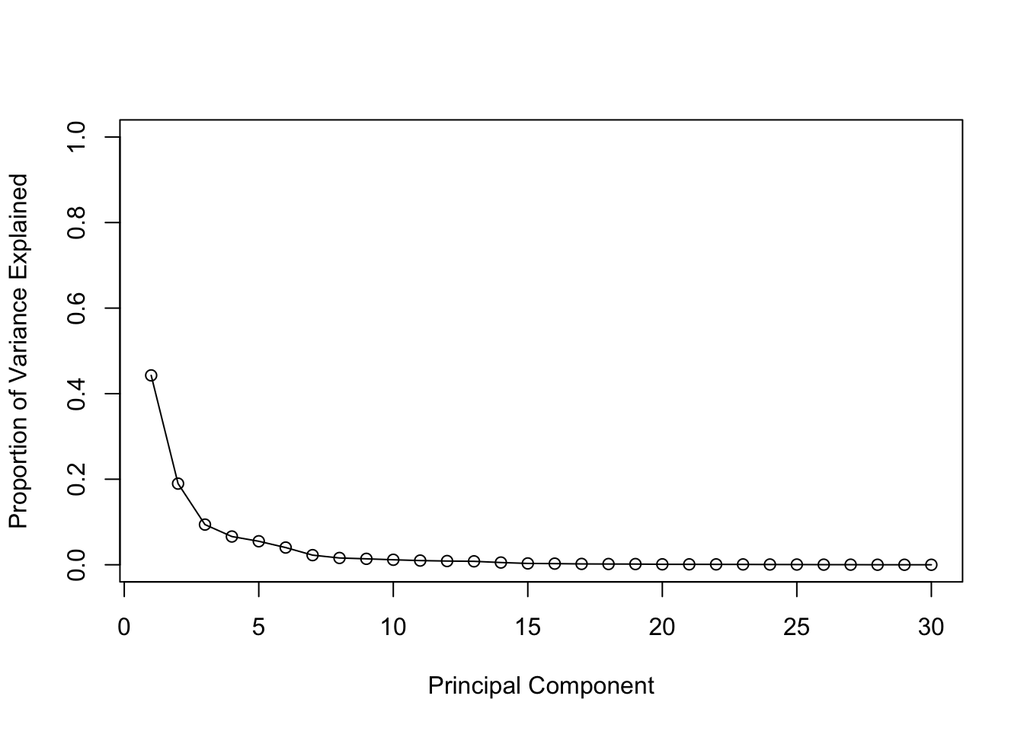

```r
pr.var <- wisc.pr$sdev^2
pve    <- pr.var / sum(pr.var)

plot(pve, xlab = "Principal Component",
     ylab = "Proportion of Variance Explained",
     ylim = c(0, 1), type = "o")
```

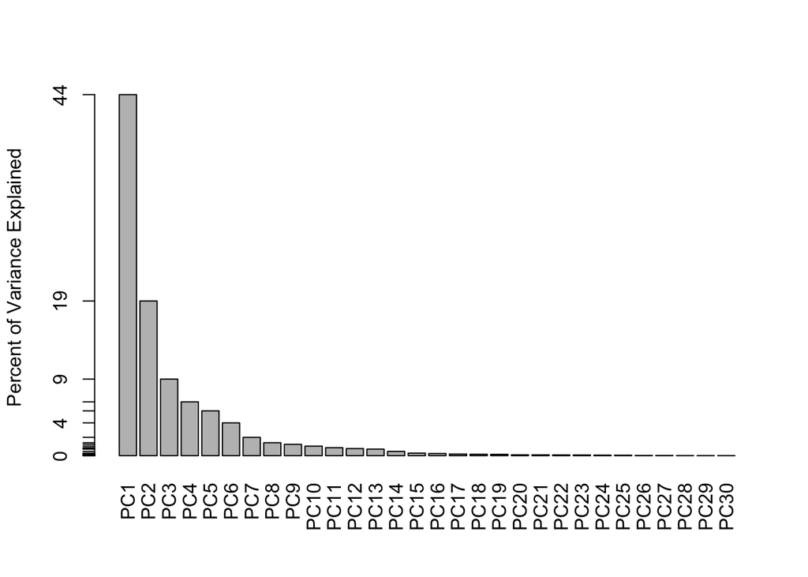

```r
barplot(pve, ylab = "Percent of Variance Explained",
        names.arg = paste0("PC", 1:length(pve)), las = 2, axes = FALSE)
axis(2, at = pve, labels = round(pve, 2) * 100)
```

Optional: a nicer scree plot with `factoextra`.

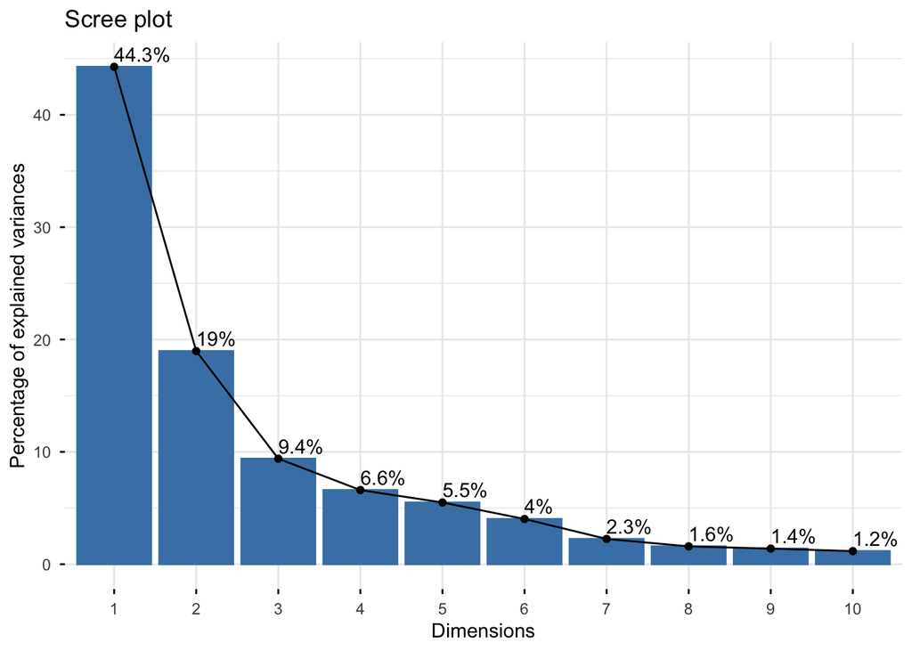

```r
library(factoextra)
fviz_eig(wisc.pr, addlabels = TRUE)
```

## 3.9 Q9. PC1 loading for `concave.points_mean`? Any larger contributions?

```r
wisc.pr$rotation["concave.points_mean", 1]
```

```
[1] -0.2608538
```

```r
sort(abs(wisc.pr$rotation[, 1]), decreasing = TRUE) |> head(10)
```

```
 concave.points_mean       concavity_mean concave.points_worst
           0.2608538            0.2584005            0.2508860
    compactness_mean      perimeter_worst      concavity_worst
           0.2392854            0.2366397            0.2287675
        radius_worst       perimeter_mean           area_worst
           0.2279966            0.2275373            0.2248705
           area_mean
           0.2209950
```

> **Answer:** The PC1 loading for `concave.points_mean` is **−0.2609**. Its absolute value (0.2609) is the **largest** of any feature on PC1, no feature contributes more to PC1. The next-largest are `concavity_mean` (0.2584), `concave.points_worst` (0.2509), and `compactness_mean` (0.2393), so the dominant drivers of PC1 are the concavity and compactness measurements, which makes biological sense: malignant cell nuclei tend to have more irregular, concave contours.

# 4 Hierarchical clustering

Hierarchical clustering on the original (scaled) 30 features.

```r
data.scaled <- scale(wisc.data)
data.dist   <- dist(data.scaled)
wisc.hclust <- hclust(data.dist, method = "complete")
```

## 4.1 Q10. Height at which the model has 4 clusters?

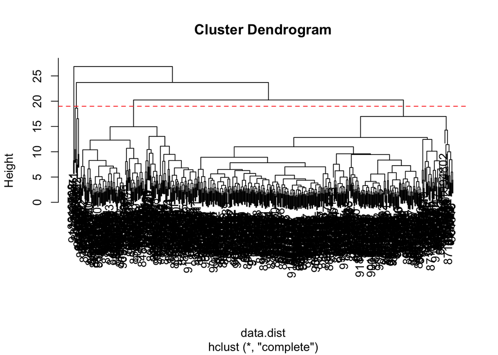

```r
plot(wisc.hclust)
abline(h = 19, col = "red", lty = 2)  # adjust height so the dashed line cuts into exactly 4 clusters
```

> **Answer:** The 4-cluster cut occurs at a **height of ≈ 19** (any height between 18.64 and 20.24 cuts the dendrogram into exactly 4 clusters; using `h = 19` gives 4 clusters).

## 4.2 Selecting number of clusters

```r
wisc.hclust.clusters <- cutree(wisc.hclust, k = 4)
table(wisc.hclust.clusters, diagnosis)
```

```
                    diagnosis
wisc.hclust.clusters   B   M
                   1  12 165
                   2   2   5
                   3 343  40
                   4   0   2
```

## 4.3 Q11. (OPTIONAL) Better cluster-vs-diagnoses match with k between 2 and 6?

```r
for (k in 2:6) {
  cat("\n--- k =", k, "---\n")
  print(table(cutree(wisc.hclust, k = k), diagnosis))
}
```

```
--- k = 2 ---
   diagnosis
      B   M
  1 357 210
  2   0   2

--- k = 3 ---
   diagnosis
      B   M
  1 355 205
  2   2   5
  3   0   2

--- k = 4 ---
   diagnosis
      B   M
  1  12 165
  2   2   5
  3 343  40
  4   0   2

--- k = 5 ---
   diagnosis
      B   M
  1  12 165
  2   0   5
  3 343  40
  4   2   0
  5   0   2

--- k = 6 ---
   diagnosis
      B   M
  1  12 165
  2   0   5
  3 331  39
  4   2   0
  5  12   1
  6   0   2
```

> **Answer (optional):** No, I could not find a clearly better split. With **complete linkage**, increasing `k` mostly produces tiny fragmented clusters rather than cleaner M/B separation. At `k = 2` and `k = 3` nearly everything is dumped into one big cluster (357 B + 210 M together), which is useless. At `k = 4` we finally get a useful split, cluster 1 is M-dominant (12 B, 165 M) and cluster 3 is B-dominant (343 B, 40 M). At `k = 5` and `k = 6` the B-dominant cluster starts splintering without improving the M/B boundary, so `k = 4` remains the best complete-linkage result.

## 4.4 Q12. Which linkage method gives your favorite results?

```r
for (m in c("single", "complete", "average", "ward.D2")) {
  cat("\n--- method =", m, "---\n")
  h <- hclust(data.dist, method = m)
  print(table(cutree(h, k = 2), diagnosis))
}
```

```
--- method = single ---
   diagnosis
      B   M
  1 357 210
  2   0   2

--- method = complete ---
   diagnosis
      B   M
  1 357 210
  2   0   2

--- method = average ---
   diagnosis
      B   M
  1 357 209
  2   0   3

--- method = ward.D2 ---
   diagnosis
      B   M
  1  20 164
  2 337  48
```

> **Answer:** **`ward.D2` is my favorite.** At `k = 2`, `single`, `complete`, and `average` linkage all collapse the data into one giant cluster (357 B + 210 M together) plus a tiny outlier group of 2–3 points, they fail to separate malignant from benign at all. `ward.D2` is the only method that produces two **balanced, biologically meaningful** clusters at `k = 2`: cluster 1 is M-dominant (20 B, 164 M) and cluster 2 is B-dominant (337 B, 48 M). This is because Ward’s method minimizes within-cluster variance at each merge, which is well-suited to data like this where the groups are roughly spherical in the scaled feature space.

# 5 Combining methods

## 5.1 Clustering on PCA results

Use the minimum number of PCs required to explain at least 90% of the variance (from Q6, typically the first 7 PCs).

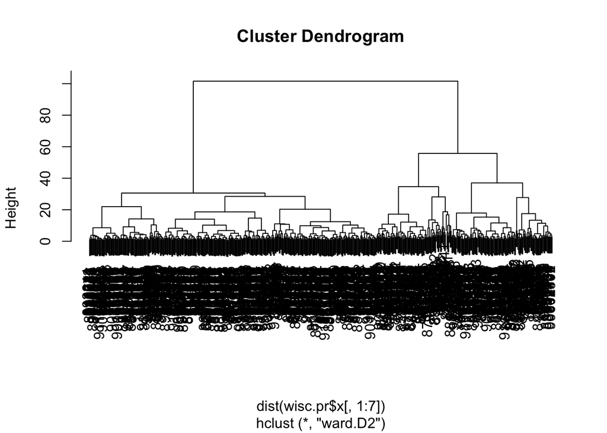

```r
wisc.pr.hclust <- hclust(dist(wisc.pr$x[, 1:7]), method = "ward.D2")
plot(wisc.pr.hclust)
```

```r
grps <- cutree(wisc.pr.hclust, k = 2)
table(grps)
```

```
grps
  1   2
216 353
```

```r
table(grps, diagnosis)
```

```
    diagnosis
grps   B   M
   1  28 188
   2 329  24
```

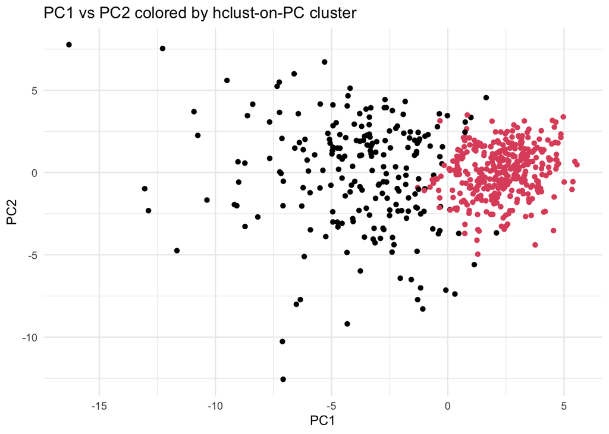

```r
ggplot(as.data.frame(wisc.pr$x)) +
  aes(PC1, PC2) +
  geom_point(col = grps) +
  theme_minimal() +
  labs(title = "PC1 vs PC2 colored by hclust-on-PC cluster")
```

```r
wisc.pr.hclust.clusters <- cutree(wisc.pr.hclust, k = 2)
```

## 5.2 Q13. How well does the new hclust model (on PCs) with 2 clusters separate M and B?

```r
table(wisc.pr.hclust.clusters, diagnosis)
```

```
                       diagnosis
wisc.pr.hclust.clusters   B   M
                      1  28 188
                      2 329  24
```

> **Answer:** The two-cluster model on the first 7 PCs separates the diagnoses **very well**. Cluster 1 contains 28 B and **188 M** (largely malignant), and cluster 2 contains **329 B** and 24 M (largely benign). That means 188 of 212 malignant samples (88.7%) and 329 of 357 benign samples (92.2%) are correctly grouped, a clean, balanced split with only about 52 misclassifications out of 569 total.

## 5.3 Q14. How well did the earlier hclust (no PCA) do?

```r
table(wisc.hclust.clusters, diagnosis)
```

```
                    diagnosis
wisc.hclust.clusters   B   M
                   1  12 165
                   2   2   5
                   3 343  40
                   4   0   2
```

> **Answer:** The original hclust on the 30 scaled features (complete linkage, `k = 4`) does a **decent but messier** job. Cluster 1 is strongly malignant (12 B, 165 M) and cluster 3 is strongly benign (343 B, 40 M), but the clean signal is spread across 4 clusters (with two tiny side clusters containing 7 and 2 points). The **PCA + `ward.D2` model is noticeably cleaner**, it achieves a similar M/B separation using only 2 clusters, captures more of the malignant samples (188 M vs 165 M in the M-dominant cluster), and produces a result that is easier to interpret and evaluate.

# 6 Sensitivity / Specificity

Given:

- **Sensitivity** = TP / (TP + FN), a fraction of true malignant samples captured by the cluster dominated by M.
- **Specificity** = TN / (TN + FP), a fraction of true benign samples captured by the cluster dominated by B.

## 6.1 Q15. (OPTIONAL) Which procedure gave the best specificity? Sensitivity?

```r
sens_spec <- function(tbl) {
  mc <- which.max(tbl[, "M"])
  bc <- which.max(tbl[, "B"])
  TP <- tbl[mc, "M"]; FN <- sum(tbl[, "M"]) - TP
  TN <- tbl[bc, "B"]; FP <- sum(tbl[, "B"]) - TN
  c(sensitivity = TP / (TP + FN), specificity = TN / (TN + FP))
}

res <- rbind(
  `PCA + hclust (ward.D2, k=2)` = sens_spec(table(wisc.pr.hclust.clusters, diagnosis)),
  `hclust (complete, k=4)`      = sens_spec(table(wisc.hclust.clusters, diagnosis))
)
round(res, 4)
```

```
                            sensitivity specificity
PCA + hclust (ward.D2, k=2)      0.8868      0.9216
hclust (complete, k=4)           0.7783      0.9608
```

> **Answer (optional):**
> - **Best sensitivity:** `PCA + hclust` (sensitivity ≈ **0.887** vs 0.778 for the raw-feature hclust). It recovers 188 / 212 malignant samples.
> - **Best specificity:** `hclust (complete, k=4)` (specificity ≈ **0.961** vs 0.922 for PCA + hclust). Its B-dominant cluster 3 has only 40 M out of 383 samples.

> In a cancer-screening context sensitivity is usually the more important metric (missing a malignant tumor is far worse than a false alarm), so **PCA + hclust is the preferred model overall**.

# 7 Prediction

Project two new patient samples onto the existing PCA space.

```r
url <- "https://tinyurl.com/new-samples-CSV"
new <- read.csv(url)
npc <- predict(wisc.pr, newdata = new)
npc
```

```
           PC1       PC2        PC3        PC4       PC5        PC6        PC7
[1,]  2.576616 -3.135913  1.3990492 -0.7631950  2.781648 -0.8150185 -0.3959098
[2,] -4.754928 -3.009033 -0.1660946 -0.6052952 -1.140698 -1.2189945  0.8193031
            PC8       PC9       PC10      PC11      PC12      PC13     PC14
[1,] -0.2307350 0.1029569 -0.9272861 0.3411457  0.375921 0.1610764 1.187882
[2,] -0.3307423 0.5281896 -0.4855301 0.7173233 -1.185917 0.5893856 0.303029
          PC15       PC16        PC17        PC18        PC19       PC20
[1,] 0.3216974 -0.1743616 -0.07875393 -0.11207028 -0.08802955 -0.2495216
[2,] 0.1299153  0.1448061 -0.40509706  0.06565549  0.25591230 -0.4289500
           PC21       PC22       PC23       PC24        PC25         PC26
[1,]  0.1228233 0.09358453 0.08347651  0.1223396  0.02124121  0.078884581
[2,] -0.1224776 0.01732146 0.06316631 -0.2338618 -0.20755948 -0.009833238
             PC27        PC28         PC29         PC30
[1,]  0.220199544 -0.02946023 -0.015620933  0.005269029
[2,] -0.001134152  0.09638361  0.002795349 -0.019015820
```

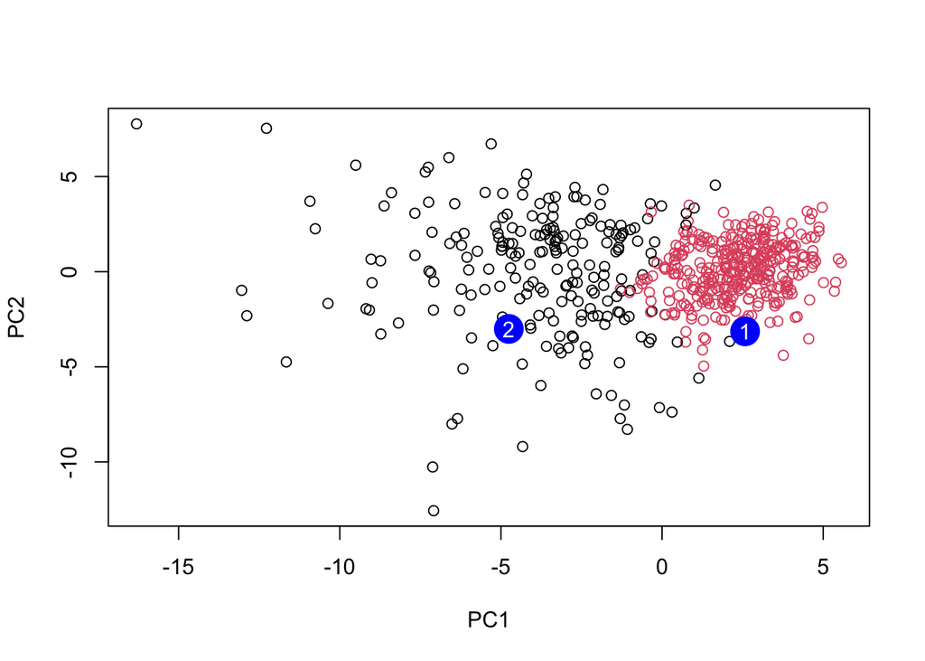

```r
plot(wisc.pr$x[, 1:2], col = grps)
points(npc[, 1], npc[, 2], col = "blue", pch = 16, cex = 3)
text(npc[, 1], npc[, 2], c(1, 2), col = "white")
```